# nickvidal

# @nickvidal – Nick Vidal

> github.com/nickvidal  
> maintaine.rs/nickvidal

*Celebrating 5 years at the Open Source Initiative: a journey of growth, challenges, and community engagement*

Reaching the five-year mark at the Open Source Initiative (OSI) has been a huge privilege. It’s been a whirlwind of progress, personal growth, and community engagement—filled with highs, great challenges, and plenty of Open Source celebrations. As I reflect on this milestone, it’s impossible not to feel both gratitude and excitement for what lies ahead. This isn’t just a story about my career—it’s about the evolution of Open Source, the incredible people I’ve worked with, and the values we’ve championed.

## Joining OSI: first steps into the journey

Back in 2017, under the leadership of OSI’s General Manager Patrick Masson, I stepped into the role of Director of Community and Development at the OSI. That year, we began planning a celebration of the 20th anniversary of Open Source for 2018, a massive undertaking. This wasn’t just about throwing a party. It was a celebration of the immense impact Open Source has had on the global tech community.

And yet, the timing was crucial. Open Source, which had steadily grown over the past two decades, faced challenges on multiple fronts: from sustainability and diversity to startups attempting to redefine the term “Open Source” and obscure its principles. The emergence of faux Open Source licenses, like the Commons Clause and the Server Side Public License, only added to the urgency of defending the very core of our mission.

## The 20th Anniversary world tour

We embarked on the OSI’s [20th Anniversary World Tour](https://opensource.org/wp-content/uploads/2014/12/2018AnnualReport.pdf) in 2018, organizing over 100 activities across 40 events globally, rallying the support of affiliates, sponsors, and the Open Source community at-large. The goal wasn’t just to celebrate but to affirm the values we held dear—transparency, collaboration, and freedom in software development. This culminated in the signing of the [Affirmation of the Open Source Definition](https://opensource.org/blog/osd_affirmation) by over 40 foundations and corporations, a powerful statement that we would not back down in the face of challenges.

[figure not shown]

## Stepping back amidst the pandemic

When the pandemic hit in 2020, everything came to a sudden halt. With schools closing and my young children—a one-year-old and a four-year-old—at home, the demands of balancing work and family life became overwhelming. I made the difficult decision to step down from my role at the OSI. It wasn’t easy to step away from something I loved, but at the time, it felt necessary.

A year later, I joined a security startup as Head of Community, where I led a cutting-edge [Open Source project](https://enarx.dev/) and held a leadership role at the [Confidential Computing Consortium](https://confidentialcomputing.io/) at the Linux Foundation. This new role allowed me to expand my expertise in community management and Open Source security—critical topics that would soon come to the forefront.

## Return to the OSI: a new chapter

In early 2023, the startup I was working for had to close its doors unfortunately. But just as one chapter ended, another began. Stefano Maffulli, OSI’s new Executive Director, reached out to me with an opportunity to return to the OSI. This time, the focus was on addressing a growing concern: the clarity around licenses and security vulnerabilities in the Open Source supply chain.

I jumped at the chance to come back. In the beginning of this new chapter, I had the opportunity to work on two challenges: to manage the [ClearlyDefined](https://docs.clearlydefined.io/) community, a project aimed at improving transparency in Open Source licensing and security, and organizing activities around the 25th Anniversary of Open Source.

## The 25th Anniversary world tour

The [25th anniversary of Open Source](https://opensource.org/blog/osi-end-of-year-review-2023) marked an incredible milestone, not just for the OSI, but for the whole tech community. We organized activities across 36 conferences from around the world with a combined attendance of over 125,000 people. We contributed with 12 keynotes, 24 talks, 6 workshops, and 18 webinars.

[figure not shown]

It was a wonderful experience connecting with organizers of these conferences and engaging with speakers, volunteers and attendees. I personally contributed to 4 keynotes, 6 talks, 15 events, and co-organized the OSI track at [All Things Open](https://2023.allthingsopen.org/schedule/) and the [Deep Dive: AI webinars](https://opensource.org/deepdive/webinars).

Throughout the year, our focus shifted from reviewing the past of Free and Open Source software to exploring the future of Open Source in this new era of AI.

## Open Source AI Definition: a new challenge

With the popularization of Generative AI, many players in industry started using “Open Source AI” to describe their projects. Legislators around the world also started drafting laws that would have a huge impact on Open Source and AI developments. Stefano was already exploring this new challenge with the [Deep Dive: AI](https://deepdive.opensource.org/) series, but we realized that establishing an [Open Source AI Definition](https://opensource.org/ai) was going to be critical. Along with the Board of Directors, we started planning a new direction for the OSI.

We organized several activities around Open Source and AI in partnership with major Open Source conferences, from talks and panels to workshops. We also launched [forums](https://opensource.org/blog/a-public-forum-to-discuss-the-open-source-ai-definition) for online discussions, and hosted webinars and town halls to make our activities more inclusive. The work felt more important than ever. A full timeline of in-person and online events is available [here](https://opensource.org/ai/timeline).

One of the biggest undertakings was organizing a multistakeholder [co-design process](https://opensource.org/ai/process), led by Mer Joyce, where we brought together global experts to establish a shared set of principles that can recreate permissionless, pragmatic and simplified collaboration for AI builders.

One of the projects I’m particularly proud of is the “[Voices of the Open Source AI Definition](https://opensource.org/blog/tag/voices)” series. Through this initiative, we’ve been able to share the stories of the volunteers from the co-design process involved in shaping the Open Source AI Definition (OSAID). These stories highlight the diversity and passion of the community, bringing a human element to the often technical discussions around Open Source and AI.

The work around the Open Source AI Definition developed by the OSI was [cited over 150 times](https://opensource.org/press-mentions) in the press worldwide, educating and countering misinformation. Our work was featured at The New York Times, The Verge, TechCrunch, ZDNET, InfoWorld, Ars Technica, IEEE Spectrum, MIT Technology Review, among other top media outlets.

## ClearlyDefined: bringing clarity to licensing

As part of my community management role on the ClearlyDefined project, I had the opportunity to contribute under the exceptional leadership of E. Lynette Rayle (GitHub) and Qing Tomlinson (SAP), whose guidance was instrumental in driving the project forward. One of my major accomplishments was the creation of a brand-new [website and comprehensive documentation](https://opensource.org/blog/unveiling-clearlydefined-this-free-sbom-service-gets-cleared-for-takeoff).

[figure not shown]

We engaged with the ORT (Open Source Review Toolkit) and Scancode communities, building stronger connections. We made important technical updates, including upgrading to the latest version of Scancode and expanding our [license support beyond just SPDX](https://opensource.org/blog/beyond-spdx-expanding-licenses-identified-by-clearlydefined) through LicenseRef, making it easier for developers and organizations to navigate the increasingly complex landscape of licensing. This important work led to the release of [version 2.0](https://opensource.org/blog/clearlydefined-v2-0-adds-support-for-licenserefs) of ClearlyDefined.

Another highlight was a new [harvester implementation for conda](https://opensource.org/blog/better-identifying-conda-packages-with-clearlydefined), a popular package manager with a large collection of pre-built packages for various domains, including data science, machine learning, scientific computing and more.

Additionally, the [adoption of ClearlyDefined by the GUAC community](https://opensource.org/blog/guac-adopts-license-metadata-from-clearlydefined) from OpenSSF was a testament to the growing importance of our work in bringing clarity to the Open Source supply chain not just in terms of licensing but also security.

[figure not shown]

[figure not shown]

[figure not shown]

We presented our work across three continents: in Europe at [ORT Community Days](https://opensource.org/blog/clearlydefined-at-the-ort-community-days), in North America at [SOSS Fusion](https://opensource.org/blog/clearlydefined-at-soss-fusion-2024-a-collaborative-solution-to-open-source-license-compliance), and in Asia at [Open Compliance Summit](https://sched.co/1mHSP).

Finally, we made progress toward a more open governance model by [electing](https://opensource.org/blog/clearlydefineds-steering-and-outreach-committees-defined) leaders for the ClearlyDefined Steering and Outreach Committees.

## Open Policy: from cybersecurity to AI

On the policy side, I had the privilege to work along with Deb Bryant and Simon Phipps, who kept track of policies affecting Open Source software, in particular the Securing Open Source Software Act in the US and the Cyber Resilience Act in Europe. As for policies involving Open Source and AI, I followed the [European AI Act and US AI Bill of Rights](https://opensource.org/blog/the-ai-renaissance-and-why-open-innovation-matters) and contributed with a compilation of a [list of compelling responses](https://opensource.org/blog/compelling-responses-to-ntias-ai-open-model-weights-rfc) from nonprofit organizations and companies to NTIA’s AI Open Model Weights RFC.

## OpenSource.net: fostering knowledge sharing

I also helped to launch [OpenSource.net](http://opensource.net/), a platform designed to foster knowledge sharing. Led by Editor-in-Chief Nicole Martinelli, this platform has become a space for diverse perspectives and contributions, furthering the reach and impact of our work.

As part of the [Practical Open Source](https://opensource.net/category/posi/) program, which facilitates discussions on doing business with and for Open Source, I was able to bring contributions from outstanding entrepreneurs and intrapreneurs.

[figure not shown]

## Looking ahead: excitement for the future

In the last 2 years at the OSI, I’ve had the privilege of publishing [over 50 blog posts](https://opensource.org/blog/author/nvidal), as well as organizing, speaking at, and attending multiple events worldwide. The work we’ve done has been both challenging and rewarding, but it’s the community—the people who believe in the power of Open Source—that makes it all worthwhile.

As I celebrate five years at the OSI, I’m more energized than ever to continue this journey. The world of Open Source is evolving, and I’m excited to be part of shaping its future. There’s so much more to come, and I can’t wait to see where the next five years will take us.  
This is more than just a personal milestone—it’s a celebration of the impact Open Source has had on the world and the endless possibilities it holds for the future.

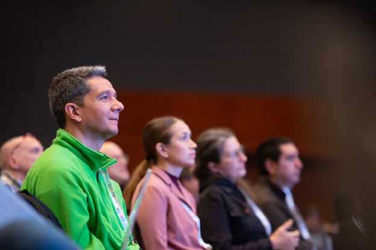

[🏠](https://maintaine.rs)